# Assignment on Central Limit Theorem

### Central Limit Theorem

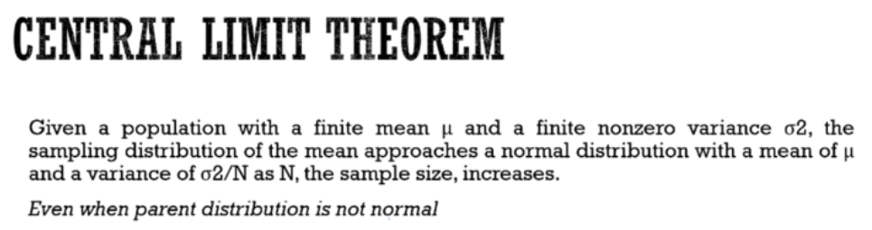

```python
import numpy as np
from scipy.stats import norm
```

### Problem 1:

Let X be a random variable with μ = 10 and σ = 4. A sample of size 100 is taken from this population. Find the probability that the sample mean of these 100 observations is less than 9.

### Explanation:

```
μ(population)  = 10
σ (population) = 4
Sample size N = 100
p(μ_sample < 9) = ?

σ (sampling distribution) = σ (population)/ sqrt(N) = 4/ sqrt(100) = 0.4
z-score = (x-u)/σ s.d = 9-10/0.4 = -1/0.4 = -2.5
p(-2.5) = 0.0062


prob = norm.cdf(-2.5)
print(prob)
```

### Answer: 0.0062

### Problem 2:

The Data Science classes are being conducted at 8th Floor of a building and students must use lift to reach there (No bonus for stair climbing!). An elevator can transport a maximum of 550 Kgs. Based on overall student’s data, it has shown that the weight of students follows a distribution with mean 50 Kgs and standard deviation 15. Suppose a team of 10 students waiting for the lift to reach the 8th Floor via the elevator. Based on this information, what is the probability that all 10 students can be safely reach the 8th floor?

### Explanation:

[output not shown]

### Problem 3:

From past experience, it is known that the number of tickets purchased by a passenger travelling from Hyderabad to Delhi in AP Express from IRCTC website in TATKAL Quota follows a distribution that has mean μ = 2.4 and sample standard deviation σ = 2.0. Suppose that before the start of booking the tickets there are 100 eager passengers logged into the website to purchase tickets. If only 250 tickets remain, what is the probability that 100 passengers will be able to purchase all the 250 tickets for their journey.

### Explanation:

[output not shown]

### Problem 4:

An officer in the army needs 35 men for a mission. He wants these soldiers to be smart enough to understand the details of the mission so the average IQ score of the 35 men must be greater than 98 pt. It is known that average IQ of a soldier is 96 with a standard deviation of 16 points. If the officer is given a random sample of 35 soldiers for the mission, what is the probability that he will get what he wants.

### Explanation:

```
μ IQ(person)  = 96
σ  (for population) = 16
Sample size N = 35
p(μ IQ(samples) >= 98) = ?

σ (sampling distribution) = σ (population)/ sqrt(N) = 16/ sqrt(35) = 2.70
z-score = (x-u)/σ s.d = 98-96/2.7 = 2/2.7 = 0.74
p (u>98) = 1- p(u<=98) = 1-p(z=0.74) = 0.229 = 0.23 = 23%

1- norm.cdf(0.74)
```

### Answer : 0.23

### Problem 5:

Engineers must consider the breadths of male heads when designing motorcycle helmets. Men have head breadths that are normally distributed with a mean of 6.0 inch and a standard deviation of 1.0 inch.

If one male is randomly selected, find the probability that his head breadth is less than 6.2 inch.

### Explanation:

[output not shown]

### Problem 6:

The lengths of pregnancies are normally distributed with a mean of 268 days and a standard deviation of 15 days. If 25 women are randomly selected, find the probability that their lengths of pregnancy have a mean that is less than 260 days.

### Explanation:

[output not shown]

### Problem 7:

If 25 women are put on a special diet just before they become pregnant and they end up having a mean length of pregnancy of less than 260 days, does it appear that the diet has an effect on the length of pregnancy?

### Problem 8:

The weights of adult males are normally distributed with a mean of 172 pounds and a standard deviation of 29 pounds. Based on this info, solve the following problems:-

a. What is the probability that one randomly selected adult male will weigh more than 190 pounds?

### Explanation:

```
μ weight(population)  = 172 pounds
σ  (for population) = 29
p(weight > 190) = ?
z-score = x-u/σ  = 190-172/29 = 18/29 = 0.62
p(weight > 190)  = 1 - p(weight <= 190) = 1- p(z=0.62) = 1-.073 = 0.27 = 27%
```

### Answer : 0.27

b. What is the probability that 25 randomly selected adult males will have a mean weight of more than 190 pounds?

### Explanation:

[output not shown]

### Problem 9:

The amount of impurity in a batch of a chemical product is a random variable with a mean value 4.0 g and a standard deviation of 1.5 g. If 50 batched are independently prepared, what is the (approx) probability that the average amount of impurity in these 50 batches is between 3.5 g and 3.8 g?

### Explanation:

[output not shown]

### Problem 10

Suppose the age a student graduates from Salem State is normally distributed. If the mean age is 23.1 years and the standard deviation is 3.1 years, what is the probability that 6 randomly selected students had a mean age at graduation that was greater than 27?

### Explanation:

[output not shown]

### Problem 11:

While checking receipts at Reds, it was determined that the average amount spent on food per table was $21.50 with a standard deviation of $2.22. If we can assume that the amount of money spent was normally distributed, what is the probability that the average f 8 checks is between $20 and $23?

### Explanation:

[output not shown]

### Problem 12:

Suppose the grades in a finite mathematics class are normally distributed with a mean of 75 and a standard deviation of 5.

a. What is the probability that a randomly selected student had a grade of atleast 83?

### Explanation:

[output not shown]

### Problem 13:

The average age of major league baseball players is 28.3 years and has a standard deviation of 2.3 years. If we can assume that ages are normally distributed , what is the probability that the average age of 10 randomly selected Red Sox players is less than 27 years?

### Explanation:

[output not shown]

### Sample programme to calculate probability

```python
def calc_prov(pop_mean,
              standard_deviation,
              sample_size,
              random_value=None,
              mean_value=None,
              prob_random_variable=True,
              prob_for_mean=False):
    """
    Sample programme to
    i) calculate probabiliy for normal random variable at a given value and
    ii) calculate probaility for at mean value of the sample of size N

    """
    u = pop_mean
    usample = pop_mean
    sd = standard_deviation
    N = sample_size
    sd_sample = standard_deviation/(np.sqrt(N))

    if prob_random_variable:
        zrv = (random_value - u) / sd
        p_rv = norm.cdf(zrv)
    if prob_for_mean:
        zpv = (random_value - u) / sd_sample
        p_pv = norm.cdf(zpv)

    return p_rv,p_pv
```

### ......................................................................END......................................................................